# Presentation - Rejecetion Sampling

Guðmundur Kr. Lee

9/24/2019

#### How to evaluate the target density

```r
zx <- pois$z*pois$x
x <- pois$x

target_sapply <- function(y)
{
  sapply(y, function(yy) prod(exp(yy*zx - exp(x*yy)))) / 1.05009e-41
}


target_sum <- function(y)
{
  sapply(y, function(yy) exp( sum(yy*zx - exp(x*yy)) )) / 1.05009e-41
}


target_outer <- function(y)
{
  exp( rowSums(outer(y, zx) - exp(outer(y, x))))/ 1.05009e-41

}
```

#### Our first implementation of the product is using the sapply function

#### Next we use the supply function again but since taking a product of the exponential is the same as taking the exponential of the sum of the powers instead, Which makes it a bit faster.

#### And finally we do the same but now using the Outer-function.

#### In all cases we divide with the normalizing constant that we found by integrating the functions from 0 to infinity.

#### And when we compare we see:

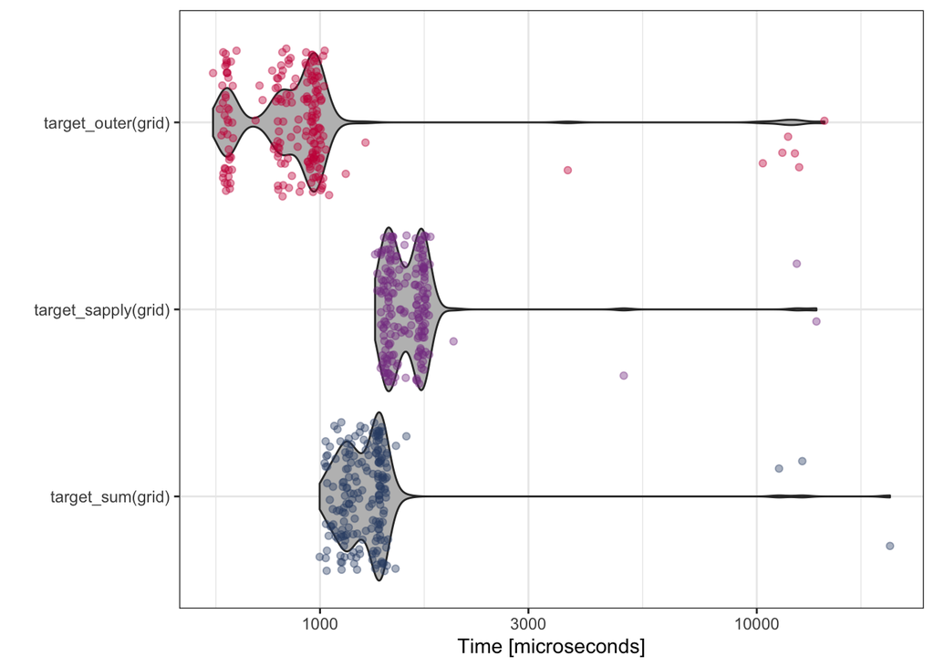

```r
p <- microbenchmark(times = 200, target_sum(grid), target_sapply(grid), target_outer(grid))
autoplot(p) + geom_jitter(aes(color = expr), alpha = 0.4) + aes(fill = I("gray"))+
  scale_color_manual(values = c("#354e75", "#884091", "#c91246", "black")) + theme_bw() +
  theme(legend.position = "none")
```

#### We see that the outer function is fastest, followed by the sapply using the sum of the powers and finally the sapply method is the slowest as one might expect.

#### Thus we can plot our target density:

```r
range(grid)
```

```
## [1] 0.0 0.5
```

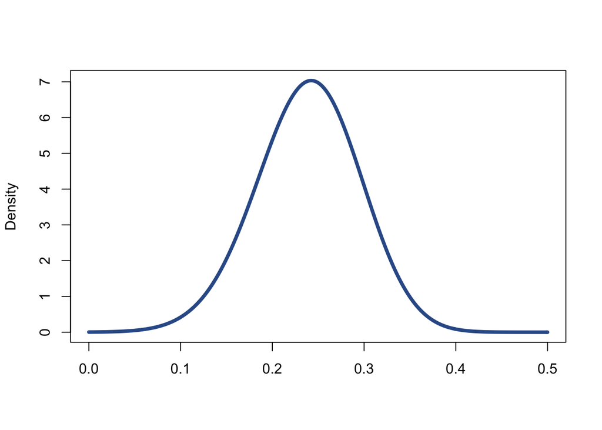

```r
plot(grid,target_outer(grid), type = "l", lwd = 4, col = "#325b96", ylab = "Density", xlab = "")
```

#### To find our Gaussian envelope, we find the mean and sd of our target density and then we use th dnorm function to get a Gaussian density.

```r
mean <- integrate(function(v) target_sapply(v)*v, 0, Inf)$value
sd <- sqrt(integrate(function(v) target_sapply(v)*v^2, 0, Inf)$value - mean^2)
targetDens <- target_outer(grid)
gausEnv <- dnorm(grid, mean, sd)
```

#### And when we add our gaussian envelope to our plot we get:

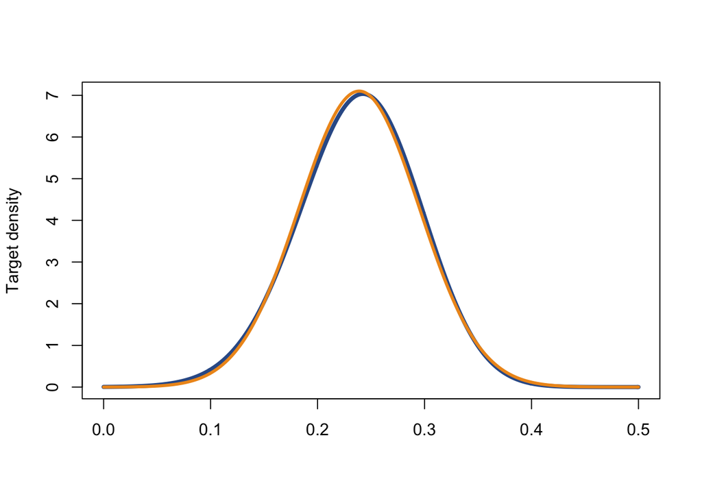

```r
plot(grid, targetDens, type = "l", lwd = 4, col = "#325b96", ylab = "Target density", xlab = "")
lines(grid, gausEnv, col = "#ee961d", lwd =3)
```

#### We now want to find our alpha-parameter so we need to find the minimum of

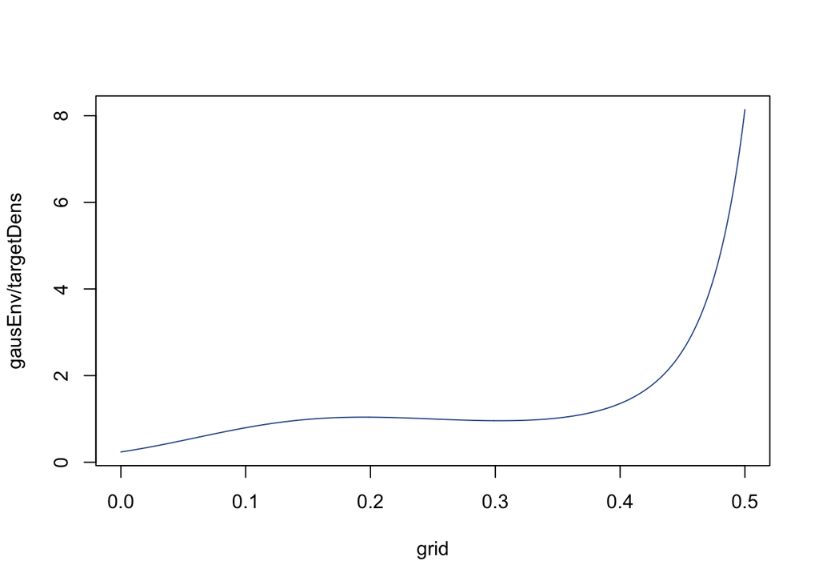

```r
plot(grid, gausEnv/targetDens, lwd =1, col = "#325b96" ,type = "l")
```

#### And by using the optimize function we get that our alpha parameter is 0.2378

```r
a <- optimize(function(z) dnorm(z, mean, sd)/target_sapply(z), c(0, 0.1))
a <- a$objective
```

####So when we plot our first envelope we get:

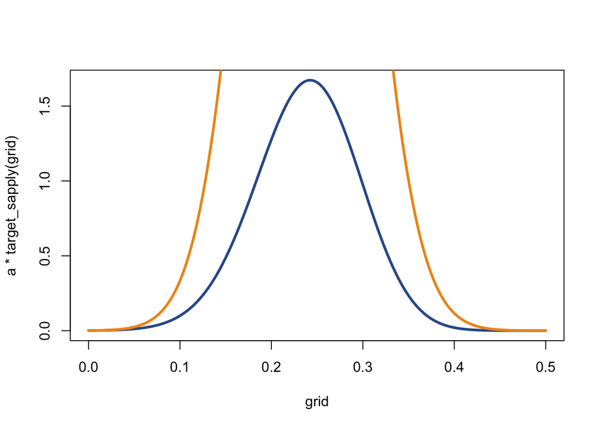

```r
plot(grid, a*target_sapply(grid), type = "l", lwd = 3,  col = "#325b96")
lines(grid, dnorm(grid, mean, sd),  col = "#ee961d", lwd =3)
```

#### And clearly this could use some improvement.